# 03 - Multi-trait Bayesian models (Diagonal, Unstructured, Factor-analytic) and GxE

Prepared by Emmanuel Ismaila for QGG, Aarhus University

# 1 Inputs

Uses the genotyped cows and the VanRaden G built in `02_genomic_prediction.Rmd`.

```r
st   <- readRDS(file.path(params$sim_dir, "burnin_state.rds")); SP <- st$SP
kern <- readRDS(file.path(params$sim_dir, "kernels.rds"))
phen <- fread(file.path(params$sim_dir, "phenotypes.csv"))
RG   <- readRDS("params/RG_matrix.rds")
h2_par <- fread("params/h2.csv")
traits <- st$traits; nT <- length(traits)
gid <- kern$gid; G <- kern$G
d <- phen[match(as.integer(gid), id)]
stopifnot(identical(as.character(d$id), gid))
d[, hg := paste(herd, generation, sep = "_g")]
cat("Genotyped cows:", nrow(d), "| generations:", paste(sort(unique(d$generation)), collapse = ","), "\n")
```

```
## Genotyped cows: 1509 | generations: 8,9,10
```

# 2 Part A - Multi-trait Bayesian GBLUP (BGLR::Multitrait)

Model, for the *n x t* matrix of phenotypes:

**Y** = **1**μ’ + **X**<sub>breed</sub>**B** + **U** + **E**, vec(**U**) ~ N(0, **Σ**<sub>G</sub> ⊗ **G**), vec(**E**) ~ N(0, **Σ**<sub>R</sub> ⊗ **I**)

Σ<sub>G</sub> and Σ<sub>R</sub> are modelled with the same structure within each model:

| Model | Σ<sub>G</sub> | Σ<sub>R</sub> |
| --- | --- | --- |
| MT-DIAG | diagonal (no genetic covariances) | diagonal |
| MT-UN | unstructured (inverse-Wishart) | unstructured |
| MT-FA | factor-analytic, k = 2 factors | factor-analytic, k = 2 |

**Pre-processing (simplification, flagged):** herd-generation means are removed from each trait before fitting (there are too many herd-generation levels to sample as fixed effects in an 11-trait MCMC). Breed is fitted as a fixed effect. Traits are standardised to unit variance so one prior scale works for all traits; correlations and h<sup>2</sup> are scale-free.

**Limitation of the simulation itself:** file 01 simulated residuals and herd effects as **independent across traits** (no residual correlations were sourced). So the true Σ<sub>R</sub> is diagonal here, and any off-diagonal in an estimated Σ<sub>R</sub> is estimation noise.

```r
# ave() keeps the row order; data.table's "by =" would regroup rows by hg and break the
# alignment with G and the true breeding values (a bug found in an earlier version)
Y <- sapply(traits, function(tr) d[[tr]] - ave(d[[tr]], d$hg))
stopifnot(identical(colnames(Y), traits), nrow(Y) == nrow(G))
Y <- scale(Y)
Xb <- model.matrix(~ breed, data = d)[, -1, drop = FALSE]
TBV <- as.matrix(d[, paste0("TBV_", traits), with = FALSE]); colnames(TBV) <- traits

# Validation: youngest generation
val <- which(d$generation == max(d$generation))
scenarios <- list(
  all_masked = { Ym <- Y; Ym[val, ] <- NA; Ym },
  # realistic: N traits recorded on few cows -> NUE and MUN missing, other traits observed
  N_masked   = { Ym <- Y; Ym[val, c("NUE", "MUN")] <- NA; Ym })
sapply(scenarios, function(m) colSums(is.na(m)))
```

```
##       all_masked N_masked
## MY           503        0
## PY           503        0
## SF           503        0
## SCS          503        0
## LNVAR        503        0
## ICF          503        0
## LONG         503        0
## MUN          503      503
## NUE          503      503
## CH4          503        0
## FY           503        0
```

```r
eigG <- eigen(G + 1e-6 * diag(nrow(G)), symmetric = TRUE)  # reused by every RKHS fit
cov_spec <- function(type) switch(type,
  DIAG = list(type = "DIAG"),
  UN   = list(type = "UN"),
  FA   = list(type = "FA", M = matrix(TRUE, nT, params$fa_factors), varimax = TRUE, var = 100))

run_mt <- function(Ym, type) {
  tmp <- tempfile("mt_"); dir.create(tmp)
  Multitrait(y = Ym,
             ETA = list(list(X = Xb, model = "FIXED"),
                        list(EVD = eigG, model = "RKHS",
                             Cov = cov_spec(type))),
             resCov = cov_spec(type),
             nIter = params$mt_iter, burnIn = params$mt_burn, thin = 5,
             saveAt = paste0(tmp, "/"), verbose = FALSE)
}

mt <- list()
for (sc in names(scenarios)) for (type in c("DIAG", "UN", "FA")) {
  fm <- run_mt(scenarios[[sc]], type)
  # keep only what is used later (full fits hold large matrices -> out of memory)
  mt[[paste(sc, type)]] <- list(ETA = list(NULL, list(Cov = list(Omega = fm$ETA[[2]]$Cov$Omega),
                                                       u = fm$ETA[[2]]$u)),
                                resCov = list(R = fm$resCov$R), fit = list(DIC = fm$fit$DIC))
  rm(fm); invisible(gc())
  progress(sc, " ", type, " done ", format(Sys.time() - t0))
}
```

[output not shown]

[output cut: 73 more lines]

[output not shown]

## 2.1 Variance components and heritability

```r
vc_mt <- rbindlist(lapply(c("DIAG", "UN", "FA"), function(type) {
  fm <- mt[[paste("all_masked", type)]]
  SG <- fm$ETA[[2]]$Cov$Omega; SR <- fm$resCov$R
  data.table(model = paste0("MT-", type), trait = traits,
             h2 = diag(SG) / (diag(SG) + diag(SR)))
}))
# true h2 within breed x generation, as in file 02 (breed and herd x generation are fixed effects)
h2_true <- data.table(trait = traits, h2_true_sample = sapply(traits, function(tr) {
  dd <- d[-val]; t <- dd[[paste0("TBV_", tr)]]; yc <- dd[[tr]] - ave(dd[[tr]], dd$hg)
  var(t - ave(t, dd$breed, dd$generation)) / var(yc - ave(yc, dd$breed, dd$generation)) }))
kable(merge(dcast(vc_mt, trait ~ model, value.var = "h2"), h2_true, by = "trait"), digits = 3,
      caption = "Posterior-mean h2 by covariance structure vs simulated h2 in the training cows")
```

Posterior-mean h2 by covariance structure vs simulated h2 in the training cows

| trait | MT-DIAG | MT-FA | MT-UN | h2_true_sample |
| --- | --- | --- | --- | --- |
| CH4 | 0.198 | 0.182 | 0.205 | 0.197 |
| FY | 0.229 | 0.176 | 0.265 | 0.374 |
| ICF | 0.159 | 0.150 | 0.186 | 0.044 |
| LNVAR | 0.188 | 0.204 | 0.233 | 0.243 |
| LONG | 0.140 | 0.136 | 0.181 | 0.057 |
| MUN | 0.221 | 0.210 | 0.236 | 0.196 |
| MY | 0.294 | 0.276 | 0.321 | 0.433 |
| NUE | 0.210 | 0.187 | 0.231 | 0.123 |
| PY | 0.210 | 0.679 | 0.248 | 0.338 |
| SCS | 0.135 | 0.142 | 0.180 | 0.103 |
| SF | 0.235 | 0.233 | 0.274 | 0.226 |

## 2.2 Genetic correlations: recovered vs simulated

Three references are shown: the input r<sub>g</sub> matrix from file 00 (40 of 55 pairs sourced; the rest implied by weighted bending), the **realised** correlation among true breeding values in the training cows, and the estimates.

```r
rg_of <- function(S) { r <- cov2cor(S); dimnames(r) <- list(traits, traits); r }
real_rg <- cor(TBV[-val, ])
pairs <- which(upper.tri(RG), arr.ind = TRUE)
rg_tab <- rbindlist(lapply(c("UN", "FA"), function(type) {
  est <- rg_of(mt[[paste("all_masked", type)]]$ETA[[2]]$Cov$Omega)
  data.table(model = paste0("MT-", type), t1 = traits[pairs[, 1]], t2 = traits[pairs[, 2]],
             input = RG[pairs], realised = real_rg[pairs], estimated = est[pairs])
}))
kable(rg_tab[abs(input) > 0, ], digits = 2, caption = "Pairs with a sourced (non-zero) input rg")
```

Pairs with a sourced (non-zero) input rg

| model | t1 | t2 | input | realised | estimated |
| --- | --- | --- | --- | --- | --- |
| MT-UN | MY | PY | 0.83 | 0.74 | 0.20 |
| MT-UN | MY | SF | 0.27 | 0.29 | 0.13 |
| MT-UN | PY | SF | 0.27 | 0.34 | -0.07 |
| MT-UN | MY | SCS | 0.22 | 0.17 | -0.01 |
| MT-UN | PY | SCS | 0.21 | 0.25 | -0.13 |
| MT-UN | SF | SCS | 0.07 | 0.05 | -0.04 |
| MT-UN | MY | LNVAR | 0.63 | 0.64 | 0.31 |
| MT-UN | PY | LNVAR | 0.33 | 0.25 | -0.12 |
| MT-UN | SF | LNVAR | 0.05 | 0.12 | 0.07 |
| MT-UN | SCS | LNVAR | 0.32 | 0.27 | 0.05 |
| MT-UN | MY | ICF | 0.29 | 0.31 | 0.00 |
| MT-UN | PY | ICF | 0.29 | 0.18 | 0.12 |
| MT-UN | SF | ICF | 0.06 | 0.18 | -0.16 |
| MT-UN | SCS | ICF | 0.15 | 0.03 | -0.05 |
| MT-UN | LNVAR | ICF | 0.40 | 0.48 | 0.13 |
| MT-UN | MY | LONG | -0.06 | -0.20 | -0.05 |
| MT-UN | PY | LONG | 0.39 | 0.42 | 0.24 |
| MT-UN | SF | LONG | 0.01 | 0.11 | -0.12 |
| MT-UN | SCS | LONG | -0.20 | -0.03 | -0.07 |
| MT-UN | LNVAR | LONG | -0.16 | -0.27 | -0.03 |
| MT-UN | ICF | LONG | -0.15 | -0.22 | 0.16 |
| MT-UN | MY | MUN | -0.10 | -0.01 | 0.10 |
| MT-UN | PY | MUN | 0.10 | 0.23 | 0.08 |
| MT-UN | SF | MUN | 0.03 | 0.12 | -0.01 |
| MT-UN | SCS | MUN | -0.14 | -0.08 | 0.05 |
| MT-UN | LNVAR | MUN | -0.07 | -0.01 | -0.02 |
| MT-UN | ICF | MUN | -0.11 | -0.10 | 0.01 |
| MT-UN | LONG | MUN | 0.26 | 0.34 | 0.00 |
| MT-UN | MY | NUE | 0.53 | 0.35 | -0.06 |
| MT-UN | PY | NUE | 0.77 | 0.76 | 0.28 |

[output cut: 80 more lines]

```r
kable(rg_tab[, .(rmse_vs_realised = sqrt(mean((estimated - realised)^2)),
                 cor_with_realised = cor(estimated, realised)), by = model], digits = 3)
```

| model | rmse_vs_realised | cor_with_realised |
| --- | --- | --- |
| MT-UN | 0.245 | 0.628 |
| MT-FA | 0.262 | 0.562 |

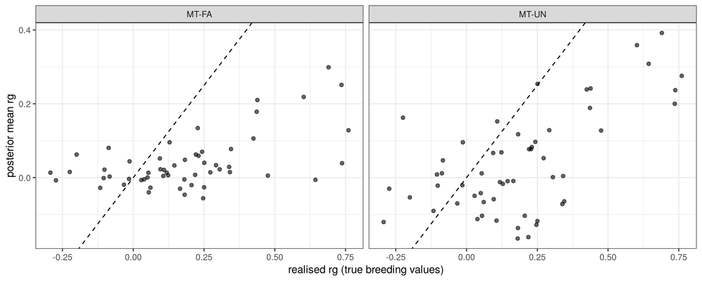

```r
ggplot(rg_tab, aes(realised, estimated)) + geom_abline(lty = 2) + geom_point(alpha = .6) +
  facet_wrap(~model) + labs(x = "realised rg (true breeding values)", y = "posterior mean rg") +
  theme_bw()
```

**Prior-dominance check.** BGLR sets default priors so that, a priori, about half of the phenotypic (co)variance is genetic (`R2 = 0.5`, split across the terms). If the posterior h<sup>2</sup> values above are similar for all traits, regardless of their very different simulated h<sup>2</sup> (0.05 for ICF/LONG vs 0.4 for MY), the data have not overcome the prior. Likewise, if estimated r<sub>g</sub> are shrunk towards 0, as happened in the TEST run (MY-PY 0.34 vs realised 0.85 with 900 cows and 600 iterations), the result reflects the prior, not the population. Conclusions about the covariance structures should only be drawn when this check passes.

## 2.3 Model fit and predictive accuracy

```r
acc_mt <- rbindlist(lapply(names(mt), function(nm) {
  fm <- mt[[nm]]; U <- fm$ETA[[2]]$u
  data.table(scenario = sub(" .*", "", nm), model = paste0("MT-", sub(".* ", "", nm)),
             trait = traits,
             acc_TBV = sapply(seq_len(nT), function(j) cor(U[val, j], TBV[val, j])),
             DIC = fm$fit$DIC)
}))
kable(dcast(acc_mt, scenario + trait ~ model, value.var = "acc_TBV"), digits = 3,
      caption = "Accuracy (cor with TBV) in the youngest generation")
```

Accuracy (cor with TBV) in the youngest generation

| scenario | trait | MT-DIAG | MT-FA | MT-UN |
| --- | --- | --- | --- | --- |
| N_masked | CH4 | 0.253 | 0.270 | 0.347 |
| N_masked | FY | 0.536 | 0.541 | 0.607 |
| N_masked | ICF | 0.107 | 0.187 | 0.310 |
| N_masked | LNVAR | 0.382 | 0.380 | 0.453 |
| N_masked | LONG | 0.140 | 0.235 | 0.122 |
| N_masked | MUN | 0.151 | 0.187 | 0.163 |
| N_masked | MY | 0.565 | 0.529 | 0.628 |
| N_masked | NUE | 0.009 | -0.037 | 0.092 |
| N_masked | PY | 0.388 | 0.347 | 0.461 |
| N_masked | SCS | 0.257 | 0.295 | 0.236 |
| N_masked | SF | 0.486 | 0.438 | 0.436 |
| all_masked | CH4 | -0.057 | 0.003 | -0.004 |
| all_masked | FY | 0.222 | 0.191 | 0.259 |
| all_masked | ICF | -0.225 | -0.011 | 0.132 |
| all_masked | LNVAR | 0.123 | 0.063 | 0.149 |
| all_masked | LONG | -0.020 | -0.046 | -0.098 |
| all_masked | MUN | 0.202 | 0.156 | 0.143 |
| all_masked | MY | 0.189 | 0.199 | 0.220 |
| all_masked | NUE | -0.026 | 0.019 | -0.036 |
| all_masked | PY | -0.042 | 0.061 | -0.040 |
| all_masked | SCS | 0.174 | 0.223 | 0.180 |
| all_masked | SF | 0.154 | 0.021 | 0.000 |

```r
kable(unique(acc_mt[, .(scenario, model, DIC)]), digits = 1, caption = "DIC (lower is better)")
```

DIC (lower is better)

| scenario | model | DIC |
| --- | --- | --- |
| all_masked | MT-DIAG | 38158.6 |
| all_masked | MT-UN | 36972.9 |
| all_masked | MT-FA | 36188.1 |
| N_masked | MT-DIAG | 53120.2 |
| N_masked | MT-UN | 52084.3 |
| N_masked | MT-FA | 53070.1 |

**How to read the N_masked scenario:** NUE and MUN are missing on validation cows while their other 9 traits are recorded. A gain of MT-UN/MT-FA over MT-DIAG for NUE there is the benefit of borrowing information through genetic correlations. Its size depends on the r<sub>g</sub> assumed in file 00, mainly NUE with MY and PY (Tavernier et al. 2024; file 00).

# 3 Part B - Genotype-by-environment (sommer)

Genetic effects of the same cow in different countries are modelled as correlated traits. Each cow is recorded in one country only, so between-country covariances are estimated through **relatives across countries** (via G).

| Model | Genetic (country x animal) | Interpretation |
| --- | --- | --- |
| M1 main | one variance | no GxE |
| M2 CS | homogeneous variance, one between-country correlation (`corgm`) | uniform GxE |
| M3 DIAG | heterogeneous variance, covariance 0 (`dsm`) | countries independent |
| M4 US | full unstructured (`usm`) | all variances and correlations |
| M5 FA | factor-analytic, 1 factor (`fam`) | parsimonious US |

Residual variance is heterogeneous by country in every model (`dsm(country)`), as in the NAV yield model (NAV May 2024, Section 4). Fixed effects: breed + herd x generation.

**THI reaction norm:** not run yet. Temperature-humidity index series for the four countries have not been sourced (see the open items in file 00).

```r
# Realised between-country genetic correlation in the simulation (truth)
# Memory: genetic values per saved generation, stacked; same rows as gv() of the merged population
GV <- do.call(rbind, lapply(unname(st$kept_cows), function(p) { g <- gv(p); rownames(g) <- p@id; g }))
GV <- GV[gid, , drop = FALSE]
countries <- unique(fread("params/breed_country_split.csv")$country)
if (st$gxe_rg < 1) {
  true_rg_c <- sapply(params$gxe_traits, function(tr) {
    cols <- paste(countries, tr, sep = "_"); r <- cor(GV[, cols])
    mean(r[upper.tri(r)])
  })
} else true_rg_c <- setNames(rep(1, length(params$gxe_traits)), params$gxe_traits)
cat("Simulated between-country rg (input):", st$gxe_rg, "\n"); print(round(true_rg_c, 3))
```

```r
Gi <- solve(0.99 * G + 0.01 * diag(nrow(G))); dimnames(Gi) <- dimnames(G)
Gu <- as(Gi, "CsparseMatrix"); attr(Gu, "inverse") <- TRUE
dg <- as.data.frame(copy(d)[, `:=`(idf = factor(as.character(id), levels = gid),
                                   country = factor(country), breed = factor(breed),
                                   hg = factor(hg))])
# REML iteration cap. The 4-country x animal Kronecker with a dense G^-1 makes each iteration
# costly (one M2_CS fit ran > 20 min at 1,500 cows with 100 iterations), so the cap is a parameter.
ctl <- mmes_control(convergence = list(maxIters = as.integer(params$gxe_reml_iter)),
                    diagnostics = list(verbose = FALSE))
fit_gxe <- function(tr, form) {
  dg$y <- dg[[tr]]
  tryCatch(mmes(y ~ breed + hg, random = form,
                rcov = ~vsm(dsm(country), ism(units)), data = dg, control = ctl),
           error = function(e) { message(tr, ": ", conditionMessage(e)); NULL })
}
forms <- list(
  M1_main = ~vsm(ism(idf), Gu = Gu),
  M2_CS   = ~vsm(corgm(country), ism(idf), Gu = Gu),
  M3_DIAG = ~vsm(dsm(country), ism(idf), Gu = Gu),
  M4_US   = ~vsm(usm(country), ism(idf), Gu = Gu),
  M5_FA   = ~vsm(fam(country, k = 1), ism(idf), Gu = Gu))
forms <- forms[intersect(c("M1_main", params$gxe_sommer_models), names(forms))]
summ_gxe <- function(fm, m) {
  if (is.null(fm)) return(NULL)
  cm <- if (m %in% c("M2_CS", "M4_US", "M5_FA"))
    tryCatch(covmatrix_mmes(fm, 1, se = TRUE), error = function(e) NULL) else NULL
  list(llik = as.numeric(fm$llik[length(fm$llik)]), convergence = fm$convergence,
       AIC = fm$AIC, BIC = fm$BIC, cm = cm)
}
gxe <- list()
for (tr in params$gxe_traits) for (m in names(forms)) {
  gxe[[paste(tr, m)]] <- summ_gxe(fit_gxe(tr, forms[[m]]), m); invisible(gc())
  progress(tr, " ", m, " done ", format(Sys.time() - t0))
}
```

```r
gxe_tab <- rbindlist(lapply(names(gxe), function(nm) {
  fm <- gxe[[nm]]; if (is.null(fm)) return(NULL)
  tr <- sub(" .*", "", nm); m <- sub(".* ", "", nm)
  rg_c <- NA_real_; rg_se <- NA_real_
  if (m %in% c("M2_CS", "M4_US", "M5_FA")) {
    cm <- fm$cm
    if (!is.null(cm)) {
      ut <- upper.tri(cm$correlation)
      rg_c  <- mean(cm$correlation[ut])
      if (!is.null(cm$correlation.se)) rg_se <- mean(cm$correlation.se[ut])  # mean of pairwise SEs
    }
  }
  data.table(trait = tr, model = m, llik = fm$llik,
             converged = isTRUE(as.logical(fm$convergence)), AIC = fm$AIC, BIC = fm$BIC,
             rg_between = rg_c, rg_se = rg_se, true_rg = true_rg_c[[tr]])
}))
# Extra genetic (co)variance parameters relative to M1 (1 variance), for nC countries
nC <- length(countries)
# M3 (r_g = 0 between countries) is NOT nested in M1 (r_g = 1): no LRT for M3
extra_par <- c(M1_main = 0, M2_CS = 1, M3_DIAG = NA,
               M4_US = nC * (nC + 1) / 2 - 1, M5_FA = 2 * nC - 1)
gxe_tab[, df := extra_par[model]]
gxe_tab[, LRT := 2 * (llik - llik[model == "M1_main"]), by = trait]
gxe_tab[, p_LRT := ifelse(!is.na(df) & df > 0, pchisq(pmax(LRT, 0), df, lower.tail = FALSE), NA_real_)]
gxe_tab[, rg_upper95 := rg_between + 1.96 * rg_se]
kable(gxe_tab[order(trait, AIC)], digits = 3,
      caption = "GxE model comparison: REML log-likelihood, LRT against M1, between-country rg with SE")
```

**Decision rule.** GxE is declared important for a trait only if, for M2, M4 or M5, **both**:

1. the REML likelihood-ratio test against M1 has p < 0.05 (same fixed effects in all models, so REML likelihoods are comparable; the chi-square reference is conservative because variances sit on a boundary under H<sub>0</sub>), **and**
2. the upper 95% limit of the between-country r<sub>g</sub> (estimate + 1.96 SE) is below 0.80, the threshold Robertson (1959) proposed as biologically important.

Otherwise one joint evaluation across countries (the NAV approach) is retained.

*Transparency note:* an earlier version of this rule used BIC plus the point estimate only. On the TEST control data, simulated with **no GxE** (r<sub>g</sub> = 1), that rule produced a false positive for NUE (estimated r<sub>g</sub> = 0.38, unstructured model preferred by BIC). The rule was tightened to the one above **after** seeing that control result and **before** any FULL-scale results existed. The r<sub>g</sub> = 1 dataset is always analysed alongside the r<sub>g</sub> = 0.9 dataset as the negative control.

```r
dec <- gxe_tab[model %in% c("M2_CS", "M4_US", "M5_FA"),
               .(GxE_declared_REML = any(p_LRT < 0.05 & rg_upper95 < 0.80, na.rm = TRUE)), by = trait]
kable(dec)
```

## 3.1 Bayesian multi-country model (BGLR)

The same GxE question in a Bayesian framework: each **country is a trait** (Falconer’s correlated-trait view of GxE), with an **unstructured** 4 x 4 genetic covariance and the eigen-decomposed G. Each cow is recorded in one country only, so residual covariances between countries are not identifiable and the residual covariance is **diagonal**. Phenotypes are pre-corrected for herd x generation (nested in country); breed is a fixed effect. This model is cheap (G is decomposed once), so it gives all six country-pair correlations with posterior credible intervals.

**Prior sensitivity.** With each cow in one country, between-country covariances are informed only through relatives, so the inverse-Wishart prior can dominate. On the TEST negative control (no GxE simulated), a prior centred on r<sub>g</sub> = 0 produced posterior r<sub>g</sub> of 0.48 (MY) and -0.04 (NUE) with narrow intervals, a false positive. Each trait is therefore fitted under **two opposite priors** with the same weight (df<sub>0</sub> = number of countries + 2) and the same prior genetic variance (0.5 on the standardised scale):

- prior A: prior mean r<sub>g</sub> = 0 between countries;
- prior B: prior mean r<sub>g</sub> = 0.95 between countries.

**Decision rule (Bayesian):** GxE is declared only if the upper 95% credible limit of the mean between-country r<sub>g</sub> is below 0.80 (Robertson 1959) under **both** priors. If the two priors disagree, the data are reported as **uninformative** about GxE.

```r
if (!exists("eigG")) eigG <- eigen(G + 1e-6 * diag(nrow(G)), symmetric = TRUE)
if (!exists("Xb"))   Xb   <- model.matrix(~ breed, data = d)[, -1, drop = FALSE]
thin_b <- 5
vech_to_cor <- function(v, k) {
  M <- matrix(0, k, k); M[lower.tri(M, diag = TRUE)] <- v      # BGLR vech: column-major lower
  M <- M + t(M) - diag(diag(M)); cov2cor(M)
}
df0_b <- nC + 2
prior_S0 <- function(r0) { V <- 0.5 * ((1 - r0) * diag(nC) + r0 * matrix(1, nC, nC)); V * (df0_b - nC - 1) }
gxe_b <- rbindlist(lapply(params$gxe_traits, function(tr) {
  y  <- d[[tr]] - ave(d[[tr]], d$hg)
  Yc <- matrix(NA_real_, nrow(d), nC, dimnames = list(NULL, countries))
  Yc[cbind(seq_len(nrow(d)), match(d$country, countries))] <- y
  Yc <- scale(Yc)
  rbindlist(lapply(c(A_rg0 = 0, B_rg095 = 0.95), function(r0) {
    tmp <- tempfile("gxeb_"); dir.create(tmp)
    fm <- Multitrait(y = Yc, ETA = list(list(X = Xb, model = "FIXED"),
                                        list(EVD = eigG, model = "RKHS",
                                             Cov = list(type = "UN", df0 = df0_b, S0 = prior_S0(r0)))),
                     resCov = list(type = "DIAG"), nIter = params$mt_iter, burnIn = params$mt_burn,
                     thin = thin_b, saveAt = paste0(tmp, "/"), verbose = FALSE)
    S <- as.matrix(read.table(file.path(tmp, "Omega_2.dat")))
    S <- S[seq_len(nrow(S)) * thin_b > params$mt_burn, , drop = FALSE]  # samples include burn-in
    R <- lapply(seq_len(nrow(S)), function(k) vech_to_cor(S[k, ], nC))
    mean_rg <- sapply(R, function(r) mean(r[upper.tri(r)]))
    pair <- Reduce(`+`, R) / length(R)
    progress(tr, " Bayes-GxE prior r0=", r0, " done ", format(Sys.time() - t0))
    data.table(trait = tr, prior_mean_rg = r0, n_samples = length(mean_rg),
               rg_mean = mean(mean_rg), rg_lower95 = quantile(mean_rg, 0.025),
               rg_upper95 = quantile(mean_rg, 0.975),
               min_pair_rg = min(pair[upper.tri(pair)]), max_pair_rg = max(pair[upper.tri(pair)]),
               true_rg = true_rg_c[[tr]])
  }))
}))
gxe_b[, upper_below_080 := rg_upper95 < 0.80]
gxe_b_dec <- gxe_b[, .(GxE_declared_Bayes = all(upper_below_080),
                       verdict = fifelse(all(upper_below_080), "GxE",
                                 fifelse(!any(upper_below_080), "no important GxE",
                                         "uninformative (prior-dependent)"))), by = trait]
kable(gxe_b, digits = 3, caption = "Posterior between-country genetic correlation (mean over the 6 country pairs), by prior")
kable(gxe_b_dec)
```

# 4 Save

```r
if (isTRUE(params$run_gxe)) {
  fwrite(gxe_tab, file.path(params$sim_dir, "gxe_models.csv"))
  fwrite(gxe_b,   file.path(params$sim_dir, "gxe_bayes.csv"))
  fwrite(gxe_b_dec, file.path(params$sim_dir, "gxe_bayes_verdict.csv"))
}
if (isTRUE(params$run_mt)) {
  fwrite(vc_mt,  file.path(params$sim_dir, "mt_h2.csv"))
  fwrite(rg_tab, file.path(params$sim_dir, "mt_rg.csv"))
  fwrite(acc_mt, file.path(params$sim_dir, "mt_accuracy.csv"))
  saveRDS(lapply(mt, function(fm) list(SG = fm$ETA[[2]]$Cov$Omega, SR = fm$resCov$R)),
          file.path(params$sim_dir, "mt_covariances.rds"))
}
cat("Run time:", format(Sys.time() - t0), "\n")
```

```
## Run time: 4.498606 mins
```